# Data Science Capstone: Milestone Report

Dongying

10/7/2020

## Instruction

The goal of this project is just to display that you’ve gotten used to working with the data and that you are on track to create your prediction algorithm. Please submit a report on R Pubs (http://rpubs.com/) that explains your exploratory analysis and your goals for the eventual app and algorithm. This document should be concise and explain only the major features of the data you have identified and briefly summarize your plans for creating the prediction algorithm and Shiny app in a way that would be understandable to a non-data scientist manager.

You should make use of tables and plots to illustrate important summaries of the data set. The motivation for this project is to:  
1. Demonstrate that you’ve downloaded the data and have successfully loaded it in.  
2. Create a basic report of summary statistics about the data sets.  
3. Report any interesting findings that you amassed so far.  
4. Get feedback on your plans for creating a prediction algorithm and Shiny app.

## Initial Data Processing

In this session, we will download the data and do some initial processing to clean the data, make it ready for analysis. First, import the necessary packages:

```r
library(NLP)
library(tm)
library(stringi)
library(wordcloud)
library(ggplot2)
library(dplyr)
library(RWeka)
library(textmineR)
```

#### Downloading and reading the data

Download the ZIP file and then unzip it. Check if the files exist before processing.

```r
filename <- "MySwiftKey.zip"
fileURL <- "https://d396qusza40orc.cloudfront.net/dsscapstone/dataset/Coursera-SwiftKey.zip"
if (!file.exists(filename)){
        download.file(fileURL, filename, method = "curl")
}
foldername <- "final"
if (!file.exists(foldername)){
        unzip(filename)
}
```

Let first take the english language as a start, set directory to the en-US folder.

```r
setwd("/Users/dongyingwang/Documents/R-studio/DataScienceCapstone_project_MySwiftKey/final/en_US")
```

Read in 3 files into R, blogs, news and twitters:

```r
fileName = "en_US.blogs.txt"
con = file(fileName, open = "r")
lineBlogs = readLines(con, encoding='UTF-8')
close(con)
```

```r
fileName = "en_US.news.txt"
con = file(fileName, open = "r")
lineNews = readLines(con, encoding='UTF-8')
close(con)
```

```r
fileName = "en_US.twitter.txt"
con = file(fileName, open = "r")
lineTwitters = readLines(con, encoding='UTF-8')
close(con)
```

#### Sampling and cleaning the text

```r
set.seed(404) # For reproducibility
percentage = 0.005
sampleTwitters <- sample(lineTwitters, percentage*length(lineTwitters))
length(sampleTwitters)
```

```
## [1] 11800
```

```r
head(sampleTwitters)
```

```
## [1] "No, thank you... You have some good input."
## [2] "swarley is bathing himself on my final project #whatever #nobigdeal and now he just slapped madden in the face. whats going on"
## [3] "Yeah, I guess I'm the only M. Bennett fan too. I waffled on what TE to nab, but like his upside and youth."
## [4] "My momma didn't rise no fool :)"
## [5] "Word through the grapevine is that you're a fellow Trojan... Fight on."
## [6] "Oklahoma St. Has never heard of a QB spyq"
```

Then remove all weird characters and turn this data set into a corpus to do the text mining.

```r
sampleTwitters<- iconv(sampleTwitters, 'UTF-8', 'ASCII', "byte") ## Remove all weird characters
sourceVec <- VectorSource(sampleTwitters) # turn character into source object
corpVec <- VCorpus(sourceVec) # turn source object into corpus
corpVec <- tm_map(corpVec, tolower) # covert to lower case
corpVec <- tm_map(corpVec, removeWords, stopwords("english")) # remove 'a', 'an', etc.
corpVec <- tm_map(corpVec, removePunctuation)
corpVec <- tm_map(corpVec, removeNumbers)
corpVec <- tm_map(corpVec, stripWhitespace)
corpVec <- tm_map(corpVec, PlainTextDocument)
```

Another important step is to remove the offensive languages, I found the list from the website, https://www.cs.cmu.edu/~biglou/resources/.

```r
filename <- "offensive_words.txt"
fileURL <- "https://www.cs.cmu.edu/~biglou/resources/bad-words.txt"
if (!file.exists(filename)){
        download.file(fileURL, filename, method = "curl")
}
offensive_words <- readLines(filename, encoding='UTF-8')
offensive_words <- offensive_words[offensive_words != ""]
corpVec <- tm_map(corpVec, removeWords, offensive_words)
```

Let’s make a word cloud to see some most frequently used words in US twitters:

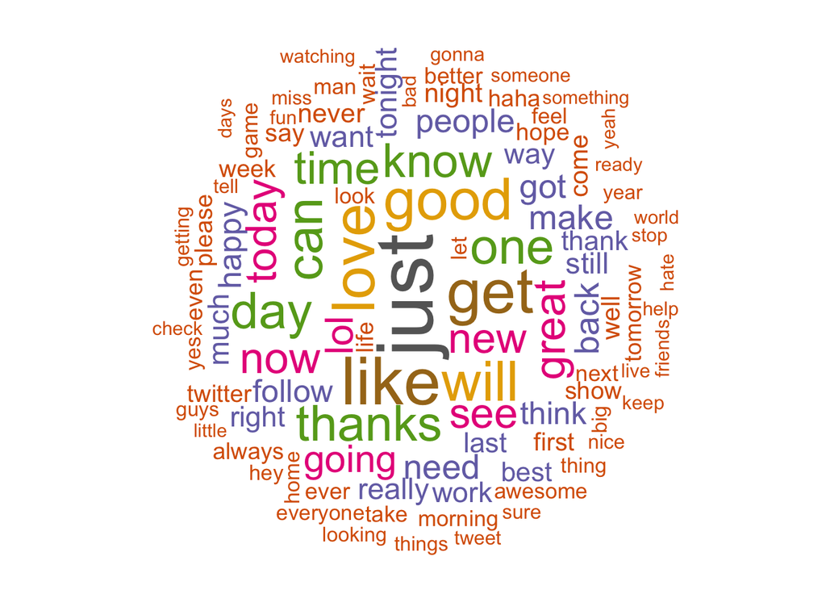

```r
wordcloud(corpVec, max.words = 100, random.order = FALSE,
          rot.per=0.35, use.r.layout=FALSE,colors=brewer.pal(8, "Dark2"))
```

## Exploratory data analysis

Let’s turn the corpus into a data frame and then look at the barplot of most frequently used words in US twitters, see if it’s consistent with the word cloud my made previously.

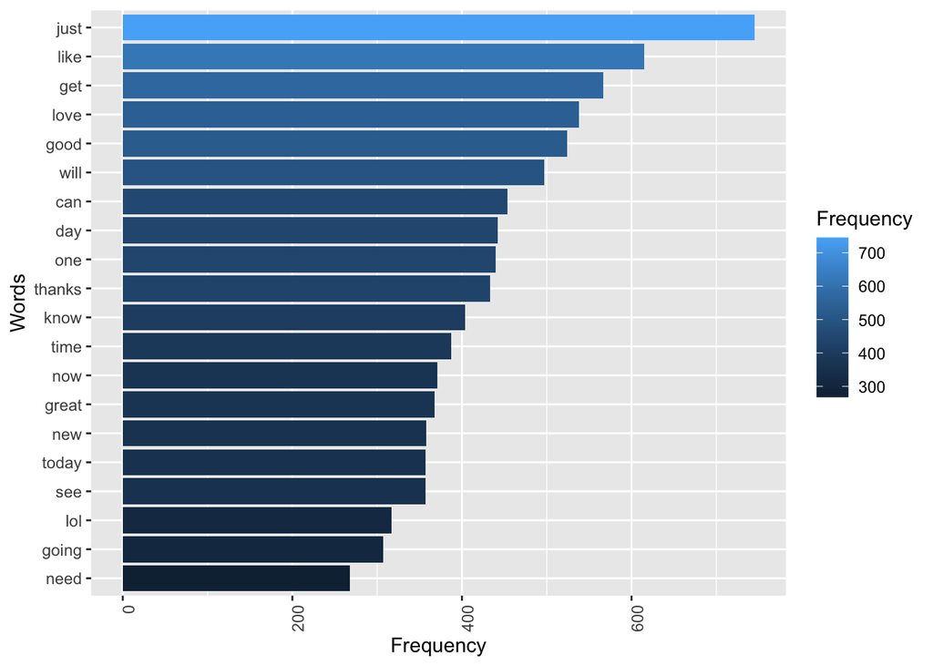

```r
UnigramTokenizer <- function(x) NGramTokenizer(x, Weka_control(min = 1, max = 1))
tdm_1 <- TermDocumentMatrix(corpVec, control = list(tokenize = UnigramTokenizer))
term_matrix_1 <- as.matrix(tdm_1)   ## convert our term-document-matrix into a normal matrix
freq_words <- rowSums(term_matrix_1)
freq_words <- as.data.frame(sort(freq_words, decreasing=TRUE))
freq_words$term <- rownames(freq_words)
colnames(freq_words) <- c("Frequency","words")
g <- ggplot(data = freq_words[1:20,],
            aes(x = reorder(words, Frequency), y = Frequency, fill = Frequency))
g + geom_bar(stat="identity") + xlab('Words') + ylab("Frequency") +
        theme(axis.text.x = element_text(angle = 90, hjust = 1)) + coord_flip()
```

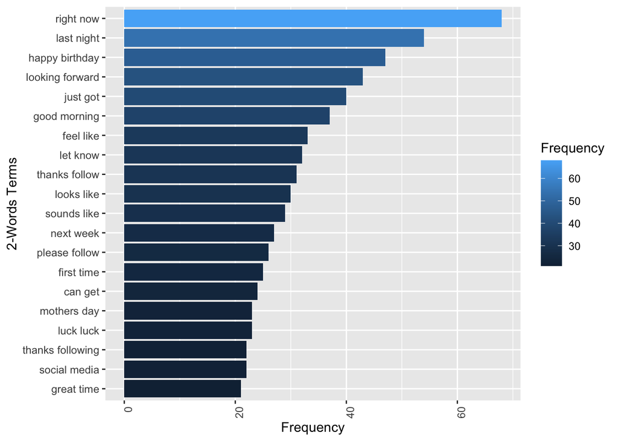

```r
BigramTokenizer <- function(x) NGramTokenizer(x, Weka_control(min = 2, max = 2))
tdm_2 <- TermDocumentMatrix(corpVec, control = list(tokenize = BigramTokenizer))
term_matrix_2 <- as.matrix(tdm_2)   ## convert our term-document-matrix into a normal matrix
freq_2words <- rowSums(term_matrix_2)
freq_2words <- as.data.frame(sort(freq_2words, decreasing=TRUE))
freq_2words$term <- rownames(freq_2words)
colnames(freq_2words) <- c("Frequency","term")
g <- ggplot(data = freq_2words[1:20,],
            aes(x = reorder(term, Frequency), y = Frequency, fill = Frequency))
g + geom_bar(stat="identity") + xlab('2-Words Terms') + ylab("Frequency") +
        theme(axis.text.x = element_text(angle = 90, hjust = 1)) + coord_flip()
```

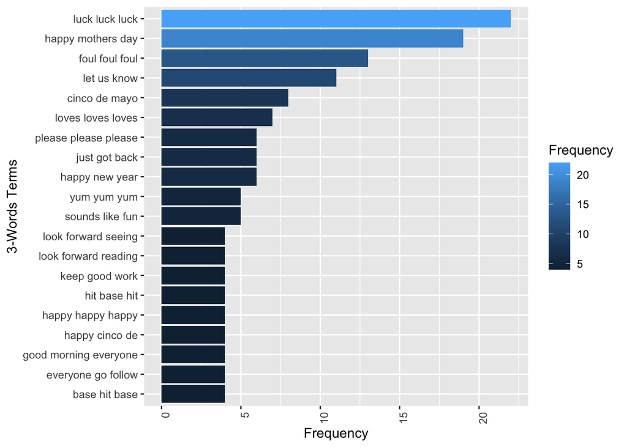

```r
TrigramTokenizer <- function(x) NGramTokenizer(x, Weka_control(min = 3, max = 3))
tdm_3 <- TermDocumentMatrix(corpVec, control = list(tokenize = TrigramTokenizer))
term_matrix_3 <- as.matrix(tdm_3)   ## convert our term-document-matrix into a normal matrix
freq_3words <- rowSums(term_matrix_3)
freq_3words <- as.data.frame(sort(freq_3words, decreasing=TRUE))
freq_3words$term <- rownames(freq_3words)
colnames(freq_3words) <- c("Frequency","term")
g <- ggplot(data = freq_3words[1:20,],
            aes(x = reorder(term, Frequency), y = Frequency, fill = Frequency))
g + geom_bar(stat="identity") + xlab('3-Words Terms') + ylab("Frequency") +
        theme(axis.text.x = element_text(angle = 90, hjust = 1)) + coord_flip()
```

## Plan for the future steps

For now, we already display the n-gram analysis to the US twitter data set. I’m now facing the data set size too large problem. In the future, that would be a main thing to fix.

Also, for the other data in blogs and news, people have different expression habits. Further more, there might be more differences when switching to another language. The final model should include all those considerations.

Finally, after further analysis, text modeling, and text prediction, I’ll implement model as a Shiny App.